# French MTPL GLM Walkthrough

# Executive Results

I wrote this notebook in the same order I actually worked through the project. I started by loading the data, then I checked whether it looked sane, then I fit a simple baseline, then I dealt with the parts that looked off, and finally I translated the results into a pricing story that feels intuitive.

The headline results are:

- average predicted annual claim frequency is 7.26%
- average predicted claim severity is EUR 2,047
- average predicted pure premium is EUR 147 per policy-year
- holdout aggregate frequency is very close: 3240 observed claims versus 3233.8 predicted
- raw severity underpredicts holdout mean severity by about -15.8%
- capped severity sensitivity is much tighter: EUR 1,626 observed versus EUR 1,648 predicted

At a high level, what I found feels pretty intuitive. Younger drivers and some higher-frequency segments come out as more expensive. The severity side is a little messier because the claim amounts have a heavy tail, so I tried to be honest about that instead of pretending the model was cleaner than it really is.

# Step 1: Load The Data And Confirm The Shape

I started with the simplest possible base-`R` import.

```r
freq <- read.csv("freMTPLfreq.csv", stringsAsFactors = FALSE)
sev <- read.csv("freMTPLsev.csv", stringsAsFactors = FALSE)

nrow(freq)
nrow(sev)
```

Then I checked that the dataset size matched what I expected after loading.

```r
checks[checks$metric %in% c("policy_rows_raw", "claim_rows_raw"), ]
```

```
##            metric  value
## 1 policy_rows_raw 413169
## 3  claim_rows_raw  16181
```

What I took from this:

- This looked right immediately.
- I have 413,169 policy rows and 16,181 claim rows.
- That lines up with the dataset description, so I did not see any sign of a bad import, broken delimiter, or accidental filtering.

# Step 2: Clean Only What We Need

I wanted this to feel like a believable actuarial baseline, not a giant preprocessing project, so I kept the cleaning deliberately light.

```r
freq <- freq[complete.cases(freq[, c(
  "PolicyID", "ClaimNb", "Exposure", "Power", "CarAge",
  "DriverAge", "Brand", "Gas", "Region", "Density"
)]), ]
freq <- freq[freq$Exposure > 0, ]
freq$logDensity <- log1p(freq$Density)

sev <- sev[complete.cases(sev[, c("PolicyID", "ClaimAmount")]), ]
sev <- sev[sev$ClaimAmount > 0, ]
```

```r
checks[checks$metric %in% c(
  "policy_rows_raw",
  "policy_rows_after_cleaning",
  "claim_rows_raw",
  "claim_rows_after_cleaning"
), ]
```

```
##                       metric  value
## 1            policy_rows_raw 413169
## 2 policy_rows_after_cleaning 413169
## 3             claim_rows_raw  16181
## 4  claim_rows_after_cleaning  16181
```

What I took from this:

- Nothing alarming happened here.
- I did not lose any rows in the light cleaning pass, which is a good sign for a clean benchmark dataset.
- I log-transformed `Density` because raw population density is highly skewed and a plain linear effect would be hard to defend.

# Step 3: Build A Train/Holdout Split

Before fitting anything, I created one fixed train/holdout split at the policy level, stratified on whether the policy had any claims.

```r
train_flag <- stratified_split(as.integer(freq$ClaimNb > 0), seed = 20260423)
freq$split <- ifelse(train_flag, "train", "holdout")

sev_model_data <- merge(
  sev,
  freq[, c("PolicyID", "split", "Power", "CarAge", "DriverAge",
           "Brand", "Gas", "Region", "Density", "logDensity")],
  by = "PolicyID",
  sort = FALSE
)
```

```r
checks[checks$metric %in% c(
  "train_policies",
  "holdout_policies",
  "train_claim_rows",
  "holdout_claim_rows"
), ]
```

```
##               metric  value
## 5     train_policies 330535
## 6   holdout_policies  82634
## 7   train_claim_rows  12941
## 8 holdout_claim_rows   3240
```

What I took from this:

- This also looked fine.
- The split keeps a large training sample and a meaningful holdout sample.
- Most importantly, claims stay attached to the same policy split, so there is no leakage from a policy’s claims into both training and validation.

# Step 4: Fit The First Frequency Model

For the first frequency model, I went with the classical starting point: a Poisson GLM with a log link and an exposure offset.

```r
freq_fit <- glm(
  ClaimNb ~ Power + CarAge + DriverAge + Brand + Gas + Region + logDensity,
  family = poisson(link = "log"),
  data = freq_train,
  offset = log(Exposure)
)
```

Then I checked whether it was at least directionally right on unseen data.

```r
holdout_summary[holdout_summary$metric %in% c(
  "Observed claims",
  "Predicted claims",
  "Observed annual frequency",
  "Predicted annual frequency",
  "Frequency dispersion"
), ]
```

```
##                       metric        value
## 1            Observed claims 3.240000e+03
## 2           Predicted claims 3.233804e+03
## 3  Observed annual frequency 6.989440e-02
## 4 Predicted annual frequency 6.976074e-02
## 9       Frequency dispersion 1.766639e+00
```

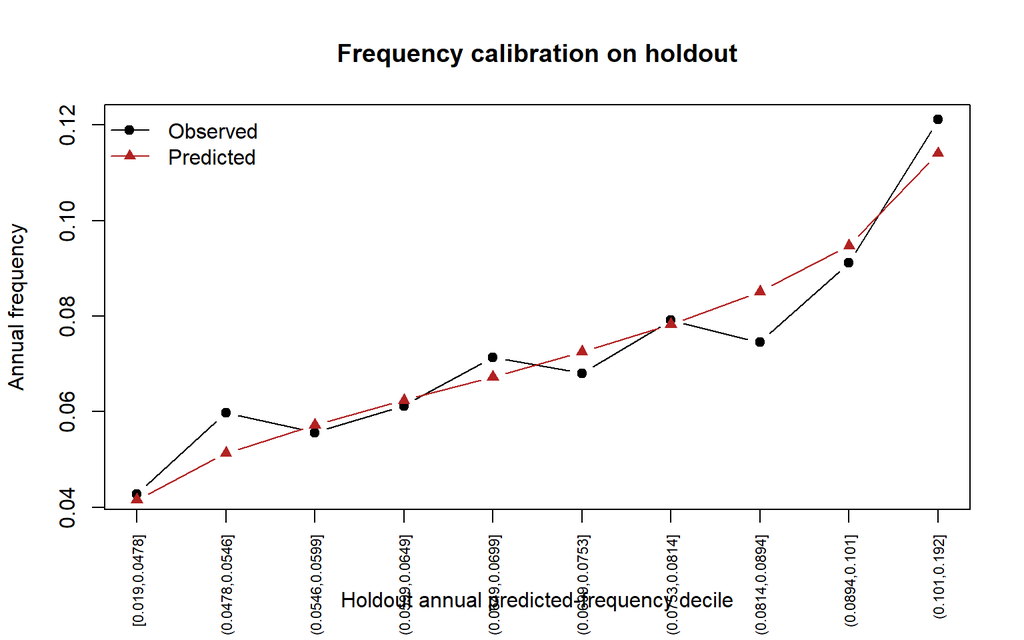

```r
freq_deciles <- results$frequency_deciles
plot(
  x = seq_len(nrow(freq_deciles)),
  y = freq_deciles$observed_frequency,
  type = "b",
  pch = 19,
  xaxt = "n",
  xlab = "Holdout annual predicted-frequency decile",
  ylab = "Annual frequency",
  main = "Frequency calibration on holdout"
)
axis(1, at = seq_len(nrow(freq_deciles)), labels = freq_deciles$decile, las = 2, cex.axis = 0.7)
lines(seq_len(nrow(freq_deciles)), freq_deciles$predicted_frequency, type = "b", pch = 17, col = "firebrick")
legend("topleft", legend = c("Observed", "Predicted"), col = c("black", "firebrick"), lty = 1, pch = c(19, 17), bty = "n")
```

What I took from this:

- The good news is that aggregate holdout frequency is excellent: 3240 observed versus 3233.8 predicted.
- The less good news is that dispersion is 1.77, which is too high for a clean Poisson inference story.
- So my basic frequency signal looked useful, but the plain Poisson standard errors were too optimistic.
- To me, that felt like a normal insurance-modeling issue, not a sign that the whole model was failing.

# Step 5: Fix Frequency Inference With Quasi-Poisson

I did not want to overreact and blow up the scope. The narrow fix was to keep the Poisson mean structure for prediction and use quasi-Poisson as the more honest inference check.

```r
freq_quasi_fit <- glm(
  ClaimNb ~ Power + CarAge + DriverAge + Brand + Gas + Region + logDensity,
  family = quasipoisson(link = "log"),
  data = freq_train,
  offset = log(Exposure)
)
```

```r
round(results$top_frequency_effects_quasi, 4)
```

```
##                                         Estimate Std. Error t value Pr(>|t|)
## Powern                                    0.2939     0.1981  1.4838   0.1378
## BrandJapanese (except Nissan) or Korean  -0.2829     0.0676 -4.1861   0.0000
## RegionLimousin                            0.2670     0.1169  2.2845   0.0223
## Powero                                    0.2591     0.2059  1.2584   0.2083
## Powerk                                    0.2531     0.0833  3.0400   0.0024
## Powerm                                    0.2017     0.1741  1.1585   0.2467
## Poweri                                    0.1879     0.0644  2.9156   0.0036
## Powerj                                    0.1537     0.0658  2.3364   0.0195
## GasRegular                               -0.1455     0.0257 -5.6646   0.0000
## Powerl                                    0.1300     0.1238  1.0506   0.2934
```

What I took from this:

- This is where the frequency story started to feel more credible.
- The main directional findings survived the quasi-Poisson adjustment, but some marginal effects became less certain once I acknowledged the extra variance.
- The most stable takeaway still feels practical rather than theoretical:
  - Regular fuel has lower predicted claim frequency than Diesel in this dataset.
  - Some Japanese/Korean brand groups show lower claim frequency.
  - Several higher power levels carry higher expected frequency.
- I do not read these as causal claims. I read them as pricing signals.

# Step 6: Fit The First Severity Model

For severity, I stuck with the classical simple choice: a Gamma GLM with a log link on positive claim amounts.

```r
sev_fit <- glm(
  ClaimAmount ~ Power + CarAge + DriverAge + Brand + Gas + Region + logDensity,
  family = Gamma(link = "log"),
  data = sev_train
)
```

```r
holdout_summary[holdout_summary$metric %in% c(
  "Observed mean severity",
  "Predicted mean severity"
), ]
```

```
##                    metric    value
## 5  Observed mean severity 2402.277
## 6 Predicted mean severity 2023.484
```

```r
round(results$top_severity_effects, 4)
```

```
##                                         Estimate Std. Error t value Pr(>|t|)
## RegionLimousin                           -0.3989     0.4515 -0.8836   0.3769
## BrandJapanese (except Nissan) or Korean   0.3903     0.2599  1.5018   0.1332
## BrandVolkswagen, Audi, Skoda or Seat      0.3900     0.2636  1.4795   0.1390
## BrandMercedes, Chrysler or BMW            0.3809     0.3037  1.2540   0.2099
## Brandother                                0.3424     0.3580  0.9567   0.3387
## Powerm                                    0.3148     0.6705  0.4696   0.6387
## Powerf                                    0.3026     0.1578  1.9177   0.0552
## BrandRenault, Nissan or Citroen           0.2992     0.2256  1.3261   0.1848
## RegionHaute-Normandie                    -0.2380     0.4321 -0.5508   0.5818
## RegionCentre                              0.1854     0.1954  0.9484   0.3429
```

What I took from this:

- This is where the first baseline started to feel less comfortable.
- Holdout mean severity is EUR 2,402, while the raw Gamma model predicts EUR 2,023.
- That is not catastrophic, but it is weak enough that I do not want to pretend the raw severity model is perfectly calibrated.
- The coefficient table also looks noisy, which is exactly what I would expect when a heavy-tailed severity distribution is being fit with a simple GLM.

# Step 7: Check The Tail And Add A Capped-Loss Sensitivity

Instead of throwing the model away, I tried to ask a better question: is the model bad everywhere, or is it mostly getting pulled around by a handful of very large losses?

The simplest stock-`R` sensitivity was to cap training severities at the 99.5th percentile and refit the Gamma model.

```r
severity_cap <- as.numeric(quantile(sev_train$ClaimAmount, probs = 0.995))
sev_train$ClaimAmountCapped <- pmin(sev_train$ClaimAmount, severity_cap)
sev_holdout$ClaimAmountCapped <- pmin(sev_holdout$ClaimAmount, severity_cap)

sev_capped_fit <- glm(
  ClaimAmountCapped ~ Power + CarAge + DriverAge + Brand + Gas + Region + logDensity,
  family = Gamma(link = "log"),
  data = sev_train
)
```

```r
holdout_summary[holdout_summary$metric %in% c(
  "Observed mean severity",
  "Predicted mean severity",
  "Observed capped mean severity",
  "Predicted capped mean severity"
), ]
```

```
##                           metric    value
## 5         Observed mean severity 2402.277
## 6        Predicted mean severity 2023.484
## 7  Observed capped mean severity 1626.456
## 8 Predicted capped mean severity 1647.553
```

```r
results$severity_cap
```

```
## [1] 36876.2
```

```r
head(round(results$severity_cooks_top, 4), 10)
```

```
##   9716   5959  11364  11439  14558   2871  13313   7584   4677   4630
## 0.1805 0.0357 0.0213 0.0204 0.0187 0.0175 0.0135 0.0115 0.0112 0.0111
```

```r
round(results$top_severity_effects_capped, 4)
```

```
##                                         Estimate Std. Error t value Pr(>|t|)
## Powerm                                    0.4225     0.2599  1.6253   0.1041
## RegionLimousin                           -0.2587     0.1750 -1.4778   0.1395
## Powern                                    0.2540     0.2953  0.8604   0.3896
## BrandJapanese (except Nissan) or Korean   0.1712     0.1008  1.6993   0.0893
## BrandMercedes, Chrysler or BMW            0.1663     0.1178  1.4125   0.1578
## Powerj                                    0.1533     0.0985  1.5569   0.1195
## RegionHaute-Normandie                    -0.1526     0.1675 -0.9110   0.3623
## Powerl                                    0.1360     0.1844  0.7378   0.4606
## BrandVolkswagen, Audi, Skoda or Seat      0.1280     0.1022  1.2531   0.2102
## Powerf                                    0.1161     0.0612  1.8982   0.0577
```

What I took from this:

- This step told me the real story.
- The cap is EUR 36,876.
- Raw holdout severity is off, but capped holdout severity is much tighter: EUR 1,626 observed versus EUR 1,648 predicted.
- That tells me the model is doing a more reasonable job on the body of the loss distribution than the raw mean alone suggests.
- In practice, I would describe the severity issue as tail sensitivity, not as a totally useless model.

# Step 8: Combine Frequency And Severity Into Pure Premium

Once I had the two pieces fit, I annualized expected frequency and multiplied by expected severity.

```r
annualized_policies$Exposure <- 1
annualized_policies$pred_frequency_annual <- predict(freq_fit, newdata = annualized_policies, type = "response")
annualized_policies$pred_severity <- predict(sev_fit, newdata = annualized_policies, type = "response")
annualized_policies$pred_pure_premium <- annualized_policies$pred_frequency_annual * annualized_policies$pred_severity
```

```r
round(quantile(results$pure_premium$pred_pure_premium, probs = c(0.1, 0.25, 0.5, 0.75, 0.9, 0.95)), 2)
```

```
##    10%    25%    50%    75%    90%    95%
##  89.10 110.39 139.45 175.36 214.93 242.35
```

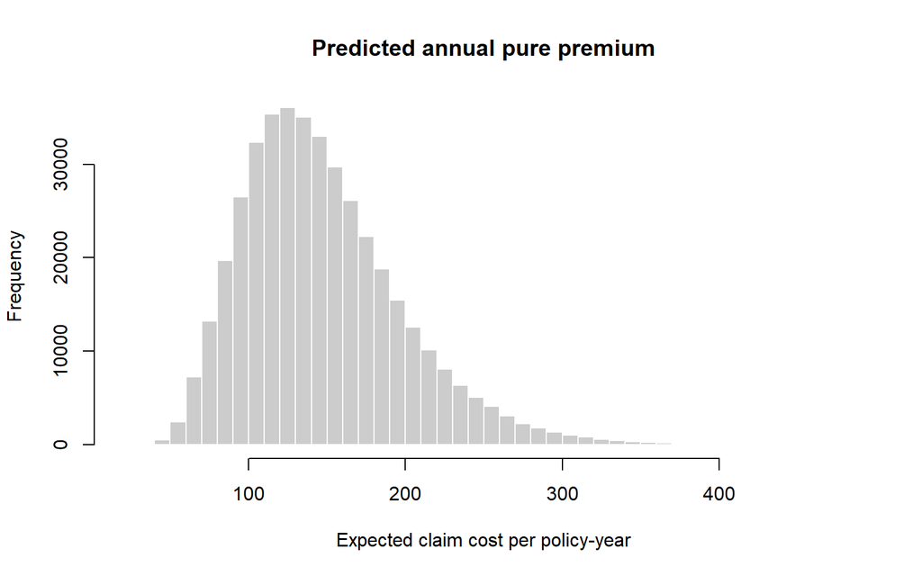

```r
hist(
  results$pure_premium$pred_pure_premium,
  breaks = 40,
  main = "Predicted annual pure premium",
  xlab = "Expected claim cost per policy-year",
  col = "gray80",
  border = "white"
)
```

What I took from this:

- The average pure premium is EUR 147 per policy-year.
- The 10th, 50th, and 90th percentiles are roughly EUR 89, EUR 139, and EUR 215.
- That spread feels meaningful, but not so extreme that the model looks unhinged.

# Step 9: Check Whether The Segmentation Makes Practical Sense

This is the part I care about most. A model can fit okay statistically and still tell a pricing story that feels silly. So I looked at a few segment summaries and example policyholders to see whether the outputs made intuitive sense.

## Age And Fuel Type Summaries

```r
age_summary
```

```
##   DriverAgeBand pred_frequency_annual pred_severity pred_pure_premium
## 1       [17,25]            0.08993528      2338.559         206.72093
## 2       (25,35]            0.08579322      2180.286         183.29805
## 3       (35,50]            0.07379741      2046.270         148.10027
## 4       (50,70]            0.06210956      1921.715         117.14645
## 5      (70,Inf]            0.04803422      1842.805          86.78069
```

```r
gas_summary
```

```
##       Gas pred_frequency_annual pred_severity pred_pure_premium
## 1  Diesel            0.07776485      1997.490          153.9203
## 2 Regular            0.06743968      2095.449          140.2727
```

What I took from this:

- Driver age behaves the way I would expect.
- The model predicts pure premium of EUR 207 for ages 17-25 and EUR 87 for ages 70+, which is a ratio of 2.38 to 1.
- That feels intuitive to me: younger drivers tend to have higher claim frequency, and in this model they also carry somewhat higher severity.
- Fuel type shows a smaller but still meaningful difference: Diesel is about 1.1 times the pure premium of Regular.
- I would not tell a causal story there. My guess is that fuel type is acting as a proxy for vehicle usage or mix.

## Example Policyholders

```r
example_display <- example_policies
numeric_cols <- vapply(example_display, is.numeric, logical(1))
example_display[numeric_cols] <- round(example_display[numeric_cols], 3)
example_display
```

```
##                     PolicyID Power CarAge DriverAge
## Lower-risk example    264256     d     13        39
## Typical example       394113     k      1        45
## Higher-risk example   138184     f      5        28
##                                                  Brand     Gas
## Lower-risk example                                Fiat Regular
## Typical example     Japanese (except Nissan) or Korean  Diesel
## Higher-risk example         Renault, Nissan or Citroen Regular
##                                 Region pred_frequency_annual pred_severity
## Lower-risk example              Centre                 0.049      1813.890
## Typical example          Ile-de-France                 0.080      1738.547
## Higher-risk example Nord-Pas-de-Calais                 0.083      2583.957
##                     pred_pure_premium
## Lower-risk example             89.102
## Typical example               139.446
## Higher-risk example           214.928
```

```r
practical_comparison
```

```
##                          comparison    ratio
## 1 Higher-risk vs lower-risk example 2.412153
## 2              Age 17-25 vs age 70+ 2.382108
## 3                 Diesel vs Regular 1.097293
```

What I took from this:

- The lower-risk example has predicted pure premium EUR 89.
- The typical example has predicted pure premium EUR 139.
- The higher-risk example has predicted pure premium EUR 215.
- The higher-risk example is about 2.41 times the lower-risk example.

Why does that happen in practice?

- The higher-risk example is worse on frequency and severity at the same time.
- Its annual predicted frequency is 8.32% versus 4.91% for the lower-risk example.
- Its predicted severity is EUR 2,584 versus EUR 1,814.
- So it is not “paying more” because of one weird coefficient. It is paying more because the model expects both more claims and more expensive claims.

Why does that broadly make sense?

- The higher-risk example is younger.
- It sits in a region with a higher modeled frequency profile.
- Its brand group and overall feature mix push severity upward as well.
- The lower-risk example, by contrast, has an older driver, lower expected frequency, and lower expected severity.

That is the way I would explain this to a non-technical person: not by reciting coefficient tables, but by showing how predicted claim count and predicted claim size combine into a higher expected annual cost.

# What Checked Out, What Did Not, And What I Changed

What checked out for me:

- dataset dimensions matched expectations
- light cleaning did not expose data-quality problems
- holdout aggregate frequency was very strong
- age segmentation makes intuitive sense
- pure premium spread across policies looks believable

What did not check out cleanly:

- Poisson dispersion was too high for a naive inference story
- raw Gamma severity underpredicted holdout mean severity
- raw severity coefficients looked noisy because of the heavy tail

What I changed:

- kept Poisson predictions but used quasi-Poisson to interpret frequency effects more honestly
- kept the raw Gamma baseline but added a capped-loss sensitivity to separate body-of-loss signal from extreme-tail noise
- rewrote the notebook around the actual modeling sequence so the reader can see the problem, the fix, and the practical implication in order

# What The Results Mean In Practice

I am not treating this as a final customer pricing model. What this notebook produces is expected claim cost per policy-year. In practice, that means:

- a policyholder costs more when the model expects them to claim more often
- a policyholder also costs more when, conditional on a claim, the model expects their claims to cost more
- the cleanest and most stable story in this notebook is on claim frequency
- severity adds signal, but that part of the story should be described more cautiously because large claims move it around

For this dataset, the practical headline feels pretty simple:

- younger drivers are materially more expensive risks in expected-loss terms
- some vehicle or usage proxies like fuel type and brand group matter as well
- the final premium differences are driven by the product of frequency and severity, not by one coefficient in isolation

# Limitations

- This is a side-project GLM baseline, not a production tariff.
- I am reading the model as association-based, not causal.
- The severity model still reacts to tail behavior even after the sensitivity check.
- Claim amounts may reflect convention-based French claims handling, which affects how I should interpret severity.
- If I were taking this further, the next steps would be richer treatment of overdispersion, more formal tail handling, and stronger governance review.